# county

Hassan

February 22, 2018

## R Markdown

countytax contains data about the tax obtained from : https://www.irs.gov/statistics/soi-tax-stats-county-data-2015

```r
  library(readr)
  countytax <- read_csv("https://www.irs.gov/pub/irs-soi/15incyallnoagi.csv")
```

now we read in the spatial data. This was obtained from https://www.census.gov/geo/maps-data/data/tiger-line.html

although more recent data is available, to conform to out tax information data we use the one from 2015.

```r
library(rgdal)
library(sf) #to add to data column
#also going to try read in as multipolygon using sf
shpdata <- st_read(dsn = "tl_2015_us_county", layer = "tl_2015_us_county", stringsAsFactors = FALSE)
library(dplyr)
statenames <- read_csv("https://raw.githubusercontent.com/jasonong/List-of-US-States/master/states.csv")
#merge(countytax, statenames, by.x="STATE", by.y = "Abbreviation")
countytax <- merge(countytax, statenames, by.x="STATE", by.y = "Abbreviation")
countytax3 <- select(countytax, State, STATE, STATEFIPS, COUNTYFIPS, COUNTYNAME, N1 , N19300, A19300, N07220,A07220 , N18425, A18425 , N18500, A18500, N59660, A59660 , N01000, A01000, N00300, A00300, N00650, A00650 , N04470, A04470, N10600, A10600)
```

A19300 = Mortgage Interest paid A18425 = state and local income tax A07220 = child tax credit A18500 = Real Estate tax A59660 = Earned Income credit

A01000 = Net capital gain (less loss) A00300 = Taxable interest amount A00650 = Qualified Dividends amount A04470 = Total itemized deductions A10600 = Total Tax payments amount

Now we move on with plotting. Its possible to plot the maps with ggplot. An example that would plot states by their color is:

ggplot(shpdata) + geom_sf(aes(fill = STATEFP),size=0.1, color = “grey40”)

To start merging data, we I’ll create a unique id by combining the stateid and countyid. The only data we need from shp is the one about the geometry.

```r
#first give the unique id to the tax data.
countytax3$uniqueID <- paste(countytax3$STATEFIPS,countytax3$COUNTYFIPS)

#then give the unique id to the location data.
shpdata$uniqueID <- paste(shpdata$STATEFP, shpdata$COUNTYFP)

#now we create a temporary version of shpdata with only the geometry and unique id
tmp <- select(shpdata, uniqueID, geometry)

#now we complete the merge
countytax4 <- merge(tmp, countytax3)

#delete all the old data files
remove(countytax)
remove(countytax3)
remove(shpdata)
remove(statenames)
remove(tmp)

#also need to rename the columns so they make more sense.
#A19300 = Mortgage Interest paid
#A18425 = state and local income tax
#A07220 = child tax credit
#A18500 = Real Estate tax
#A59660 = Earned Income credit
names(countytax4) = c("UniqueID", "State", "StateAbb", "StateFIPS", "CountyFIPS", "CountyName","NumReturns","NumMortgageI","MortgageI","NumChildTC","ChildTC", "NumStateIT","StateIT","NumRealET","RealET","NumEITC","EITC", "NumNetCapitalGain" , "NetCapitalGain","NumTaxableInterest" ,"TaxableInterest" ,"NumQDividends" ,"QDividends" ,"NumItemizedDeductions" ,"ItemizedDeductions" ,"NumTaxPayments" ,"TaxPayments" , "geometry")

#also create new columns for averages. This is done by amount divided by number of filings. Also, all the values were in thousands so multiply it by 1000 to make it easier to understand.
countytax4$AvgMortgageI <- (countytax4$MortgageI)/(countytax4$NumMortgageI)*1000
countytax4$AvgChildTC <- (countytax4$ChildTC)/(countytax4$NumChildTC)*1000
countytax4$AvgStateIT <- (countytax4$StateIT)/(countytax4$NumStateIT)*1000
countytax4$AvgRealET <- (countytax4$RealET)/(countytax4$NumRealET)*1000
countytax4$AvgEITC <- (countytax4$EITC)/(countytax4$NumEITC)*1000

countytax4$AvgNetCapitalGain <- (countytax4$NetCapitalGain)/(countytax4$NumNetCapitalGain)*1000
countytax4$AvgTaxableInterest <- (countytax4$TaxableInterest)/(countytax4$NumTaxableInterest)*1000
countytax4$AvgQDividends <- (countytax4$QDividends)/(countytax4$NumQDividends)*1000
countytax4$AvgItemizedDeductions <- (countytax4$ItemizedDeductions)/(countytax4$NumItemizedDeductions)*1000
countytax4$AvgTaxPayments <- (countytax4$TaxPayments)/(countytax4$NumTaxPayments)*1000

#also removing hawaii and alaska so theres only mainland US.
countytax <- countytax4[countytax4$State!="Hawaii", ]
countytax <- countytax[countytax$State!="Alaska", ]

remove(countytax4)
```

```r
#import necessary libraries
library(ggplot2) #to make the plot
library(RColorBrewer) #color selection

#creating a copy so the original data set is not changed
tmpdata <- countytax
```

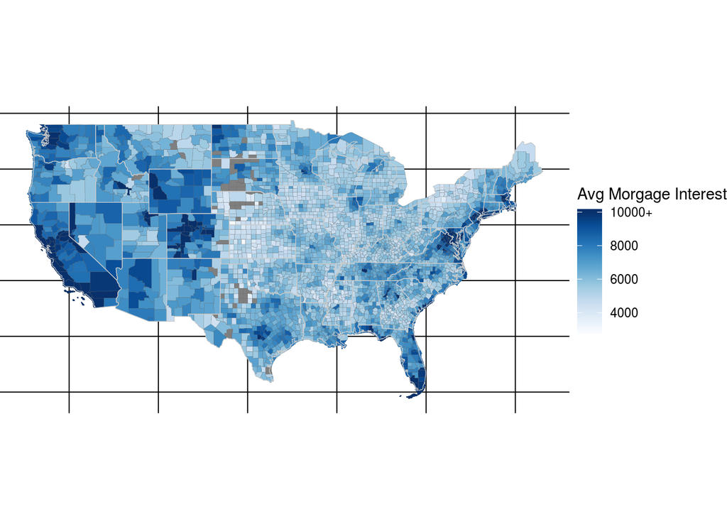

```r
#for mortgage data

tmpdata$AvgMortgageI[tmpdata$AvgMortgageI > 10000] <- 10001

ggplot(tmpdata) + geom_sf(aes(fill = tmpdata$AvgMortgageI),size=0.05, color = "grey40")+  borders(database = "state", colour ="grey80", size = 0.2) +  scale_fill_gradientn(name="Avg Morgage Interest", colors =brewer.pal(n = 9, name = "Blues"), breaks = c(4000,6000,8000,10000), labels = c("4000","6000","8000","10000+"))+theme_void()
```

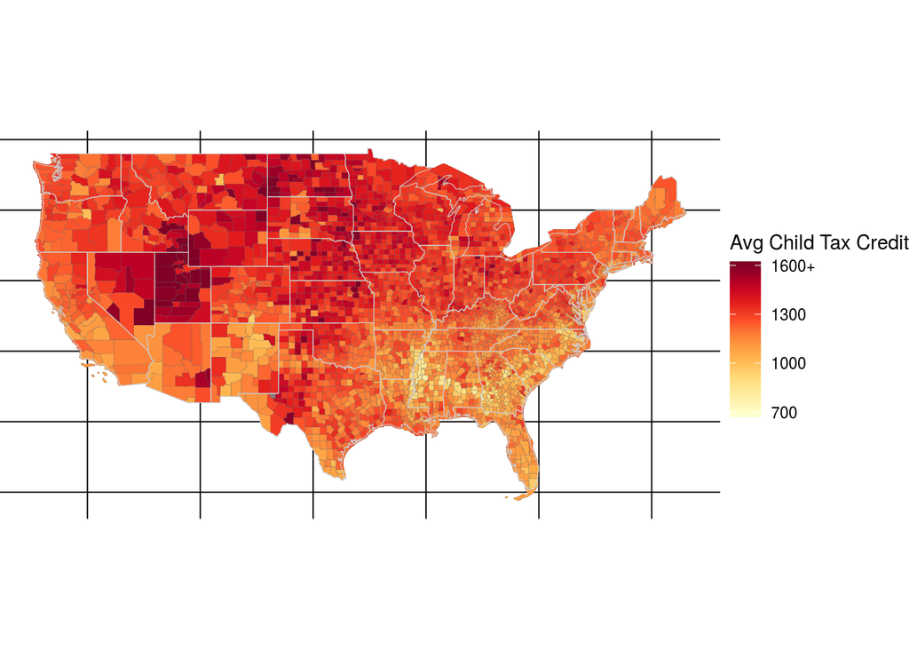

```r
#for child care tax credit
tmpdata$AvgChildTC[tmpdata$AvgChildTC > 1600] <- 1601

ggplot(tmpdata) + geom_sf(aes(fill = tmpdata$AvgChildTC),size=0.05, color = "grey40")+  borders(database = "state", colour ="grey80", size = 0.2) +  scale_fill_gradientn(name="Avg Child Tax Credit", colors =brewer.pal(n = 9, name = "YlOrRd"), breaks = c(700,1000,1300,1600), labels = c("700","1000","1300","1600+"))+theme_void()
```